# ggplot Workshop

## Customising the overall look of the plot

We can change the overall look of the plot by changing the theme. The theme will not affect how your plotted data look, just the setup of the plot:

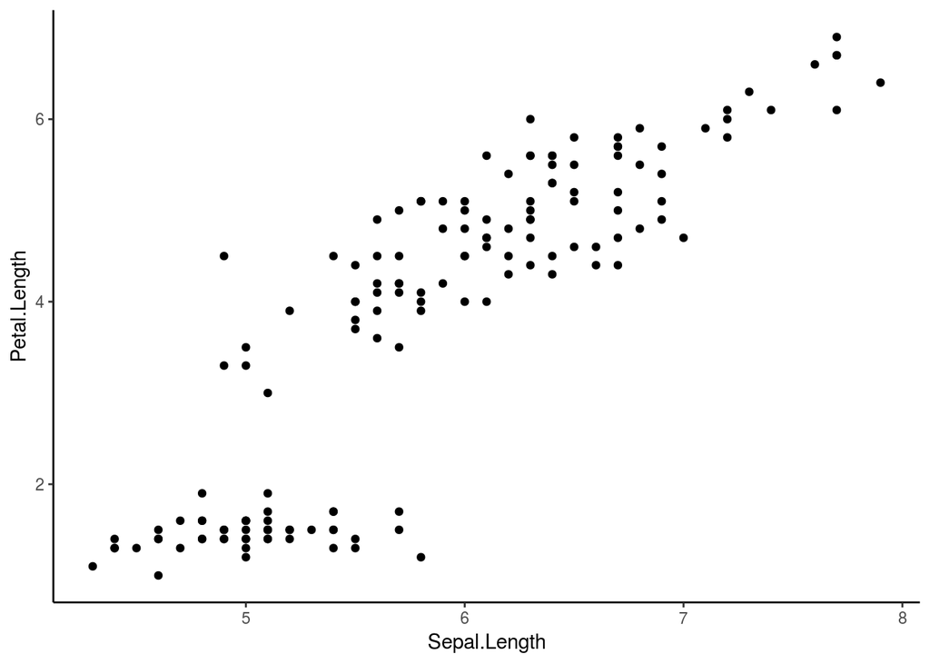

```r
ggplot(data=iris, aes(x=Sepal.Length, y=Petal.Length))+
  geom_point()+
  theme_classic()
```

For a list of themes see http://ggplot2.tidyverse.org/reference/ggtheme.html. We will look at how we can change these settings manually later.

## Using ggplot2 for different types of plots

Your plots will look different depending on the variables you are displaying - whether there are one, two or more to display, and whether they are categorical, ordinal or continuous. We will now use the dataset diamonds which is part of the ggplot2 package:

```r
str(diamonds)
```

```
## Classes 'tbl_df', 'tbl' and 'data.frame':    53940 obs. of  10 variables:
##  $ carat  : num  0.23 0.21 0.23 0.29 0.31 0.24 0.24 0.26 0.22 0.23 ...
##  $ cut    : Ord.factor w/ 5 levels "Fair"<"Good"<..: 5 4 2 4 2 3 3 3 1 3 ...
##  $ color  : Ord.factor w/ 7 levels "D"<"E"<"F"<"G"<..: 2 2 2 6 7 7 6 5 2 5 ...
##  $ clarity: Ord.factor w/ 8 levels "I1"<"SI2"<"SI1"<..: 2 3 5 4 2 6 7 3 4 5 ...
##  $ depth  : num  61.5 59.8 56.9 62.4 63.3 62.8 62.3 61.9 65.1 59.4 ...
##  $ table  : num  55 61 65 58 58 57 57 55 61 61 ...
##  $ price  : int  326 326 327 334 335 336 336 337 337 338 ...
##  $ x      : num  3.95 3.89 4.05 4.2 4.34 3.94 3.95 4.07 3.87 4 ...
##  $ y      : num  3.98 3.84 4.07 4.23 4.35 3.96 3.98 4.11 3.78 4.05 ...
##  $ z      : num  2.43 2.31 2.31 2.63 2.75 2.48 2.47 2.53 2.49 2.39 ...
```

### One continuous variable

If you have one continuous variable, you will likely use a histogram:

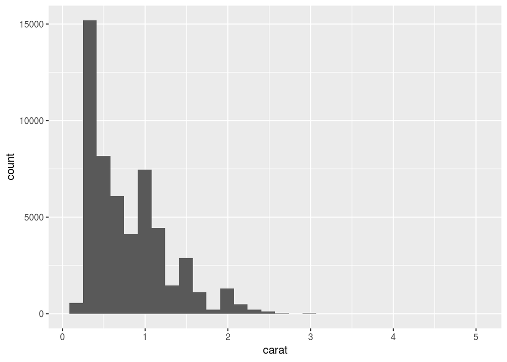

```r
ggplot(data=diamonds, aes(x=carat))+
  geom_histogram()
```

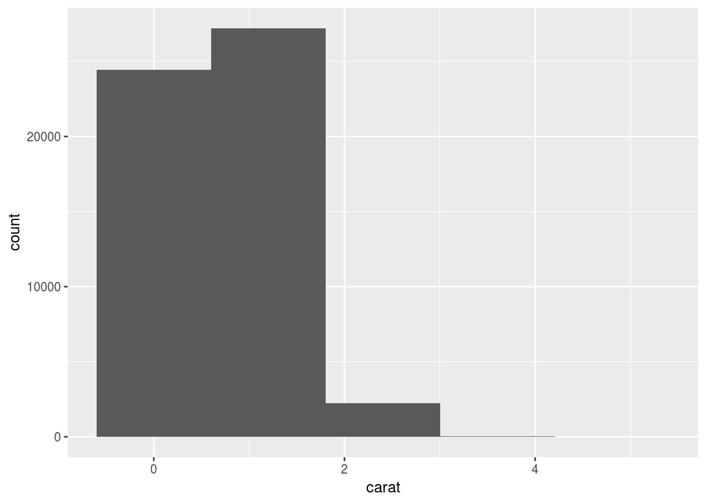

```r
ggplot(data=diamonds, aes(x=carat))+
  geom_histogram(bins=5)
```

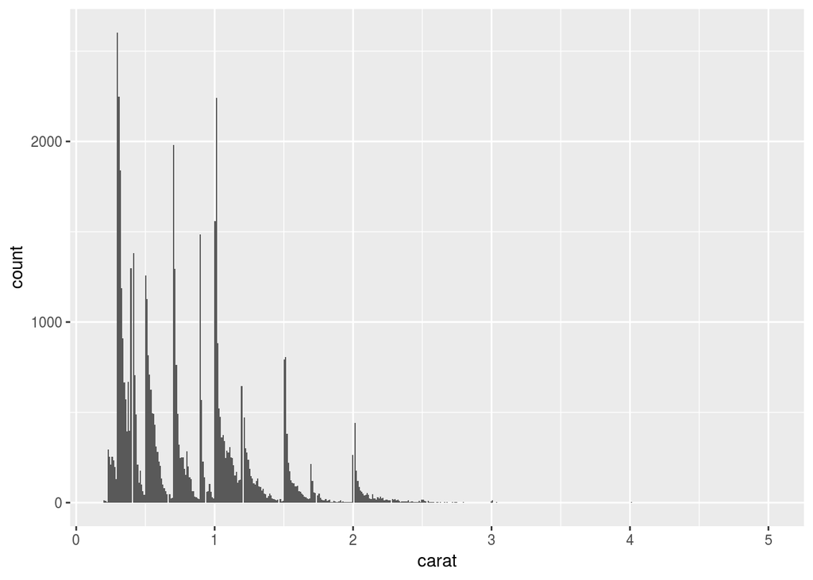

```r
ggplot(data=diamonds, aes(x=carat))+
  geom_histogram(bins=500)
```

You could also use a density plot to display one continuous variable. Note what happens to the y-axis:

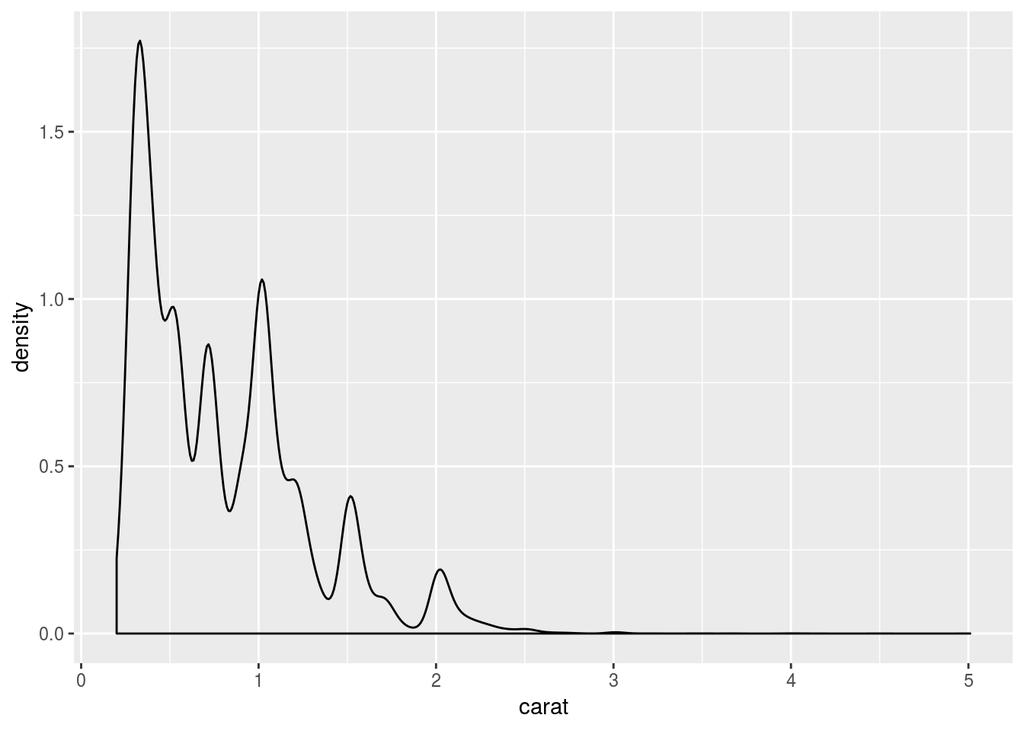

```r
ggplot(data=diamonds, aes(x=carat))+
  geom_density()
```

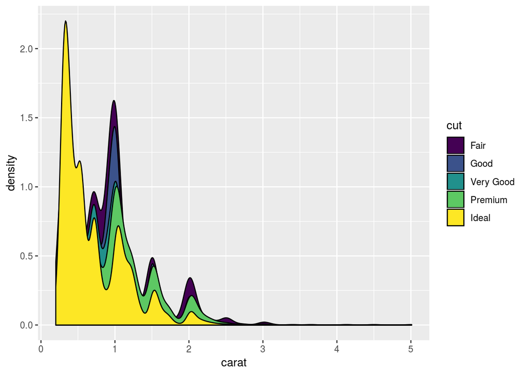

```r
ggplot(data=diamonds, aes(x=carat))+
  geom_density(aes(fill=cut))
```

what happens when you change `fill` to `colour`?

Another option would be an area plot:

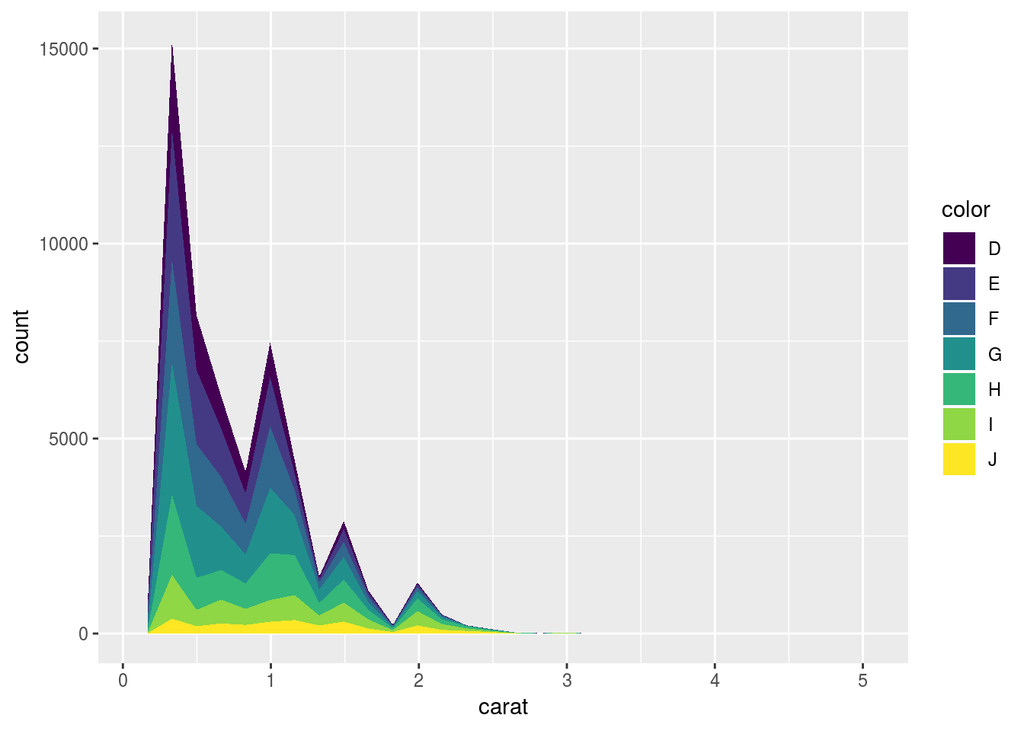

```r
ggplot(data=diamonds, aes(x=carat))+
  geom_area(stat="bin", aes(fill=color))
```

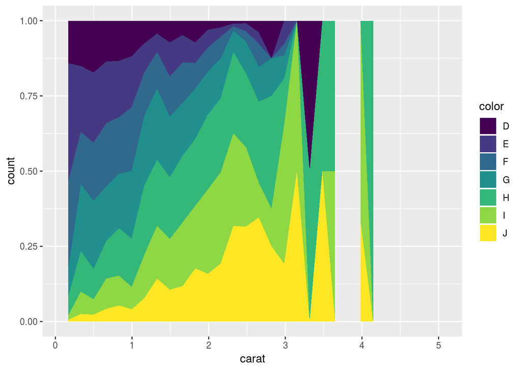

```r
ggplot(data=diamonds, aes(x=carat))+
  geom_area(stat="bin", aes(fill=color), position="fill")
```

If you change `position="stack"` (which is the default for `geom_area()`) to `position="fill"`, the plot effectively shows a percentage on the y-axis.

### One categorical variable

If you have one categorical variable, you will need a bar graph. This will show a count of each of the categories:

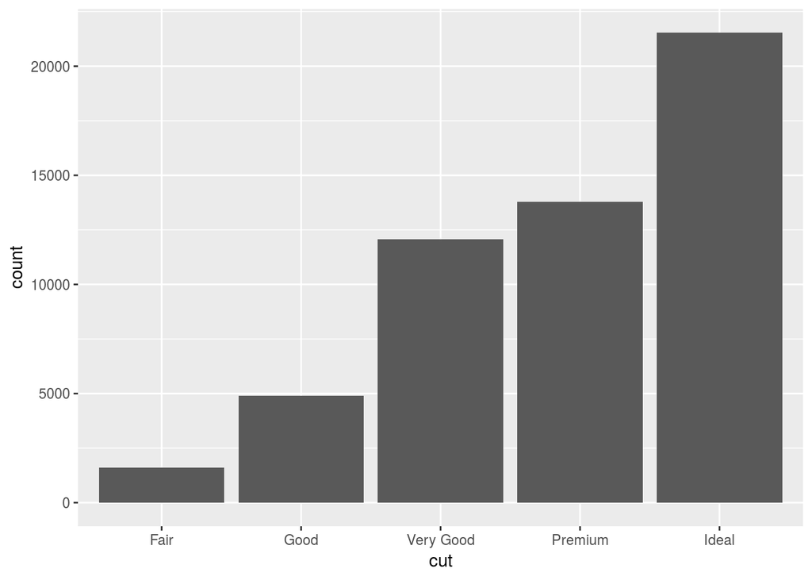

```r
ggplot(data=diamonds, aes(x=cut))+
  geom_bar()
```

### Two continuous variables

If you have two continuous variables, you normally represent them with dots - see the examples from the iris dataset we used at the start.

### One continuous and one categorical variable

If you have a categorical and a continuous variable, you would normally put the categorical variable on your x-axis and the continuous variable on your y-axis. These are often displayed as box plots (they show the four quartiles in the data, and outliers as dots):

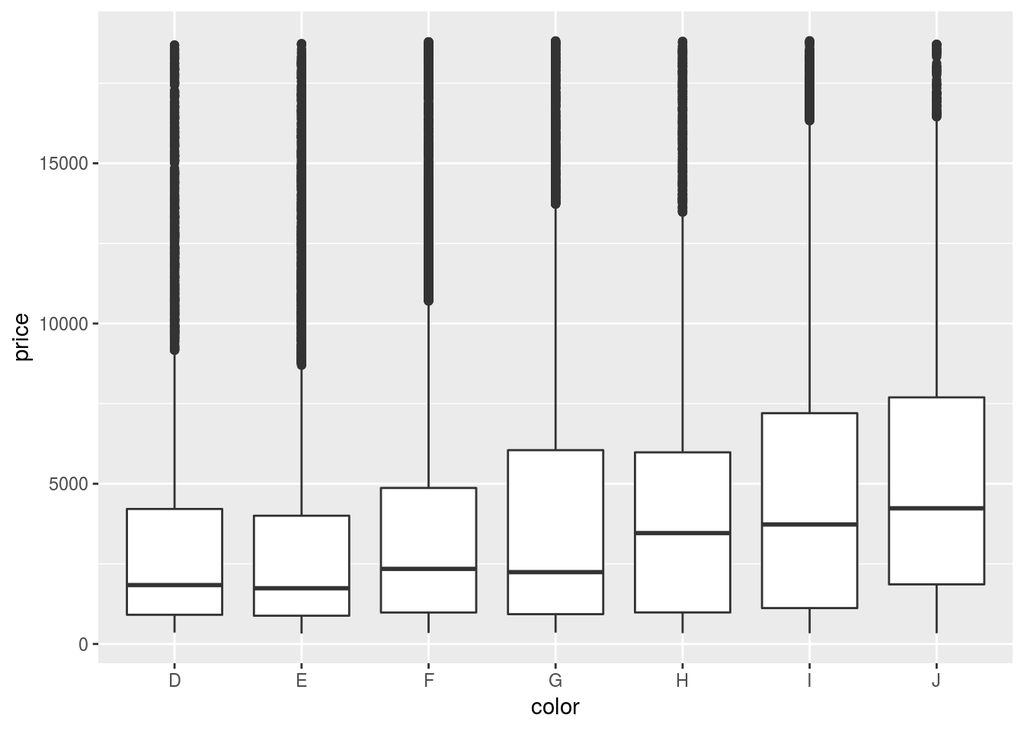

```r
ggplot(data=diamonds, aes(x=color, y=price))+
  geom_boxplot()
```

There are also other options in ggplot2 such as violin plots:

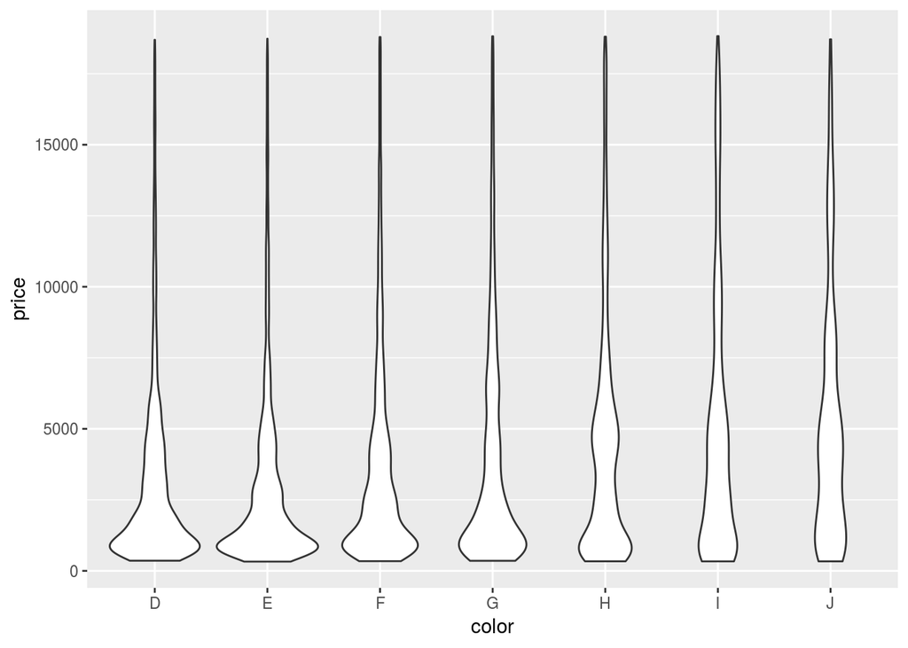

```r
ggplot(data=diamonds, aes(x=color, y=price))+
  geom_violin(scale="area")
```

Or you could present your data as a bar plot. The default `geom_bar()` option just uses a categorical variable for x. To show a categorical x and a continuous y variable, we need to add `stat="identity"` here:

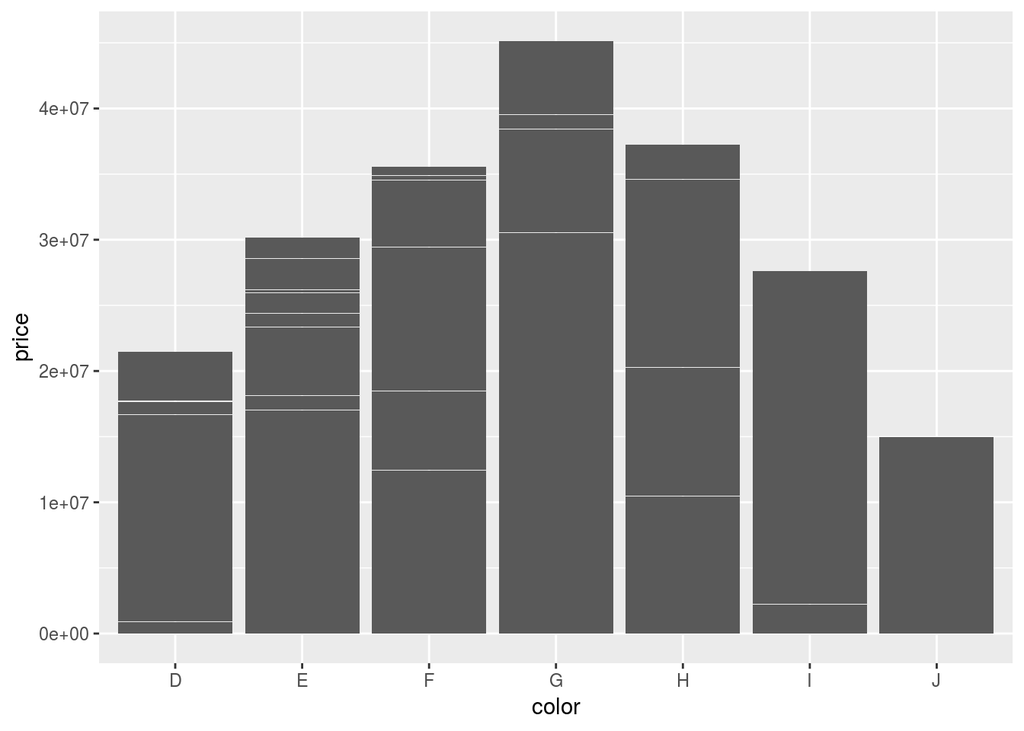

```r
ggplot(data=diamonds, aes(x=color, y=price))+
  geom_bar(stat="identity")
```

You can change the colour of the bar by another categorical variable:

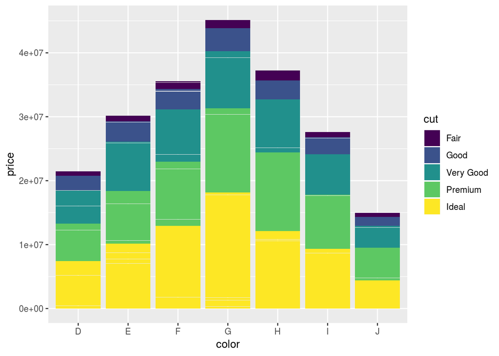

```r
ggplot(data=diamonds, aes(x=color, y=price))+
  geom_bar(aes(fill=cut), stat="identity")
```

You can also flip the x- and y-axis:

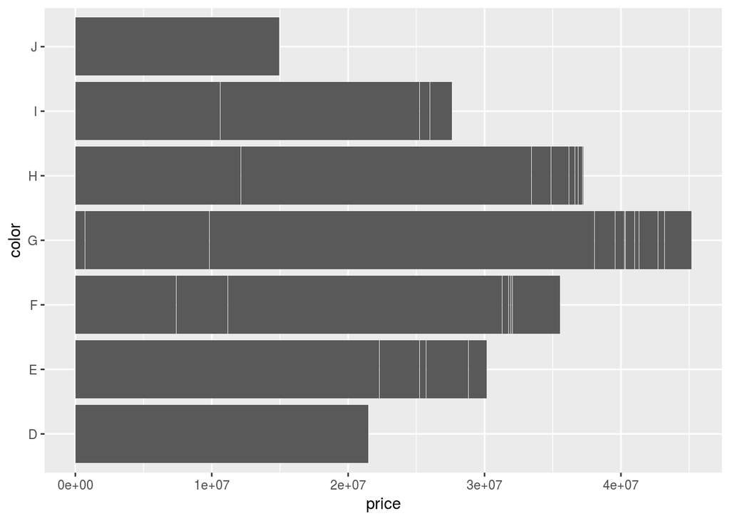

```r
ggplot(data=diamonds, aes(x=color, y=price))+
  geom_bar(stat="identity")+
  coord_flip()
```

## Adding error bars

To add error bars to a ggplot2 plot, we need to calculate the means and standard errors first. We will create a new dataset with the aggregate function. If you are unsure what your new data look like, use the `str()` or `summary()` functions:

```r
summaryd<-aggregate(price ~ color, diamonds, FUN = function(x) c(mean = mean(x), sd = sd(x),  n = length(x)))
```

We are creating a new dataframe called summaryd. In it, we are summarising the continuous variable price by the color groups. We will get a mean with `mean`, standard deviation with `sd` and number of observations with `length` of price within each color group.

```r
summaryd <- do.call(data.frame, summaryd)
# this turns it into a dataframe
summaryd$se <- summaryd$price.sd / sqrt(summaryd$price.n)
```

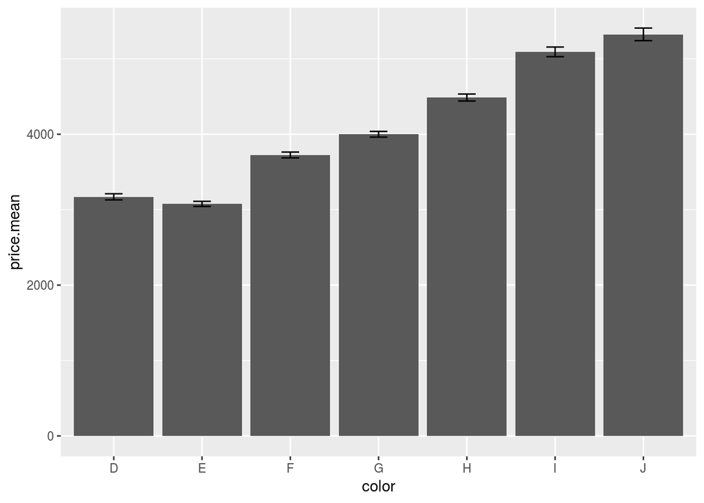

```r
ggplot(data=summaryd, aes(x=color, y=price.mean)) + geom_bar(stat="identity", position="dodge") +  geom_errorbar(aes(ymin=price.mean-se, ymax=price.mean+se), width=0.2, position="dodge")
```